# Assignment_Activity

jimmyhuang0912

June 29, 2018

## Code for reading in the dataset and/or processing the data

1. Load the data
2. Process/transform the data (if necessary) into a format suitable for your analysis

```r
data <- read.csv(file="activity.csv", header=TRUE)
```

## Mean Total Number of Steps Taken per Day

1. Calculate the total number of steps taken per day
2. If you do not understand the difference between a histogram and a barplot, research the difference between them. Make a histogram of the total number of steps taken each day

```r
install.packages("dplyr",repos="http://cran.rstudio.com/")
```

```
##
##   There is a binary version available but the source version is
##   later:
##       binary source needs_compilation
## dplyr  0.7.5  0.7.6              TRUE
```

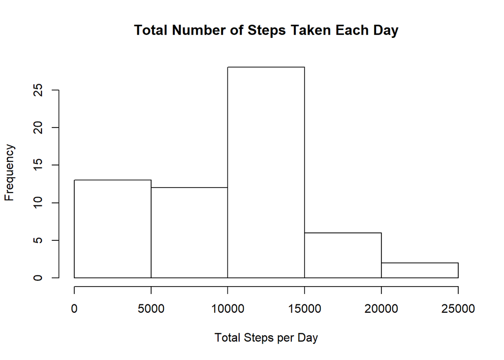

```r
library("dplyr")
date <- group_by(data, date)
data1 <- summarize(date, totalsteps = sum(steps,na.rm=TRUE))
hist(data1$totalsteps,
     main="Total Number of Steps Taken Each Day",
     xlab="Total Steps per Day")
```

3. Calculate and report the mean and median of the total number of steps taken per day

```r
meantotal <- mean(data1$totalsteps)
mediantotal <- median(data1$totalsteps)
```

- Mean Number of Steps Taken per Day = 9354.2295082
- Median Number of Steps Taken per Day = 10395

## Averag Daily Activity Pattern

1. Make a time series plot (i.e. type=“l”) of the 5-minute interval (x-axis) and the average number of steps taken, averaged across all days (y-axis)
2. Which 5-minute interval, on average across all the days in the dataset, contains the maximum number of steps?

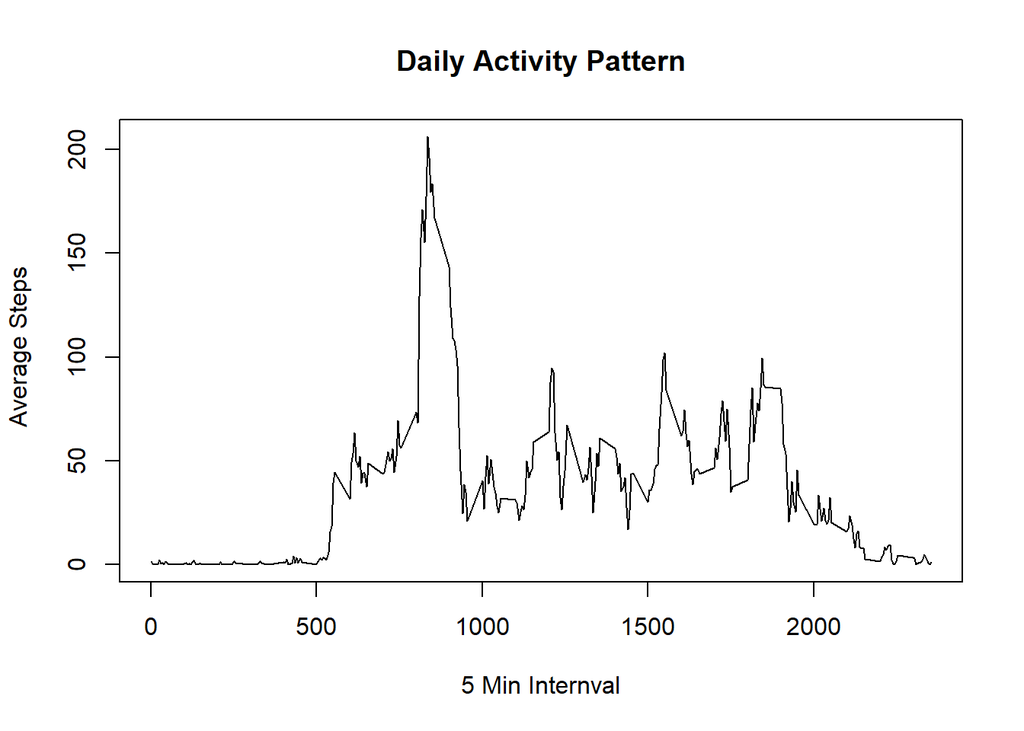

```r
int <- group_by(data, interval)
data2 <-summarize(int, meansteps = mean(steps,na.rm=TRUE))
plot(data2$interval, data2$meansteps, type="l",
     main="Daily Activity Pattern",
     xlab="5 Min Internval", ylab=" Average Steps")
```

```r
data2[which.max(data2$meansteps),]
```

```
## # A tibble: 1 x 2
##   interval meansteps
##      <int>     <dbl>
## 1      835      206.
```